# Project Milestone 2: Data Preprocessing

**CIS 4567.02**

**Project Group 4**

## Project Overview

Our project objective is to analyze recent California wildfire data, providing actionable prevention methods and recommendation to reduce future cases of high structural damage and loss.

We will be performing our analyses through Apache Spark/PySpark, with visualizations being done with small samples through Pandas.

Our data is sourced from Kaggle ([The California Wildfire Data🔥🔥🔥](https://www.kaggle.com/datasets/vijayveersingh/the-california-wildfire-data)) and contains over 100,000 observations of structural damage across various fire incidents across California from 6/6/20 to 12/9/2024.

> This dataset is sourced from the California Open Data Portal and is maintained by CAL FIRE and associated agencies.

**Variables**

```
OBJECTID: A unique identifier for each record in the dataset.
DAMAGE: Indicates the level of fire damage to the structure (e.g., "No Damage", "Affected (1-9%)").
STREETNUMBER: The street number of the impacted structure.
STREETNAME: The name of the street where the impacted structure is located.
STREETTYPE: The type of street (e.g., "Road", "Lane").
STREETSUFFIX: Additional address information, such as apartment or building numbers (if applicable).
CITY: The city where the impacted structure is located.
STATE: The state abbreviation (e.g., "CA" for California).
ZIPCODE: The postal code of the impacted structure.
CALFIREUNIT: The CAL FIRE unit responsible for the area.
COUNTY: The county where the impacted structure is located.
COMMUNITY: The community or neighborhood of the structure.
INCIDENTNAME: The name of the fire incident that impacted the structure.
APN: The Assessor’s Parcel Number (APN) of the property.
ASSESSEDIMPROVEDVALUE: The assessed value of the improved property (e.g., structures, not just land).
YEARBUILT: The year the structure was built.
SITEADDRESS: The full address of the property, including city, state, and ZIP code.
GLOBALID: A globally unique identifier for each record.
Latitude: The latitude coordinate of the structure’s location.
Longitude: The longitude coordinate of the structure’s location.
UTILITYMISCSTRUCTUREDISTANCE: The distance between the main structure and any utility or miscellaneous structures (if recorded).
FIRENAME: An alternative or secondary name for the fire incident.
geometry: A geospatial representation of the location in a point format (e.g., "POINT (-13585927.697 4646740.750)").
```

### Initialize Spark, PySpark

```python
!apt-get update # Update apt-get repository.
!apt-get install openjdk-8-jdk-headless -qq > /dev/null # Install Java.
!wget -q http://archive.apache.org/dist/spark/spark-3.1.1/spark-3.1.1-bin-hadoop3.2.tgz # Download Apache Sparks.
!tar xf spark-3.1.1-bin-hadoop3.2.tgz # Unzip the tgz file.
!pip install -q findspark # Install findspark. Adds PySpark to the System path during runtime.

# Set environment variables
import os
os.environ["JAVA_HOME"] = "/usr/lib/jvm/java-8-openjdk-amd64"
os.environ["SPARK_HOME"] = "/content/spark-3.1.1-bin-hadoop3.2"

!ls

# Initialize findspark
import findspark
findspark.init()

# Create a PySpark session
from pyspark.sql import SparkSession
spark = SparkSession.builder.master("local[*]").getOrCreate()
spark
```

[output not shown]

**SparkSession - in-memory**

**SparkContext**

[Spark UI](http://ee7fb2014d9c:4040)

**Version**

`v3.1.1`

**Master**

`local[*]`

**AppName**

`pyspark-shell`

```python
spark_df = (
    spark
    .read
    .csv(
        '/content/Postfire_Master_Data.csv',
        header=True,
        inferSchema=True
    )
)
```

### Data Cleaning

```python
spark_df.printSchema()
```

```
root
 |-- _id: string (nullable = true)
 |-- OBJECTID: string (nullable = true)
 |-- * Damage: string (nullable = true)
 |-- * Street Number: double (nullable = true)
 |-- * Street Name: string (nullable = true)
 |-- * Street Type (e.g. road, drive, lane, etc.): string (nullable = true)
 |-- Street Suffix (e.g. apt. 23, blding C): string (nullable = true)
 |-- * City: string (nullable = true)
 |-- State: string (nullable = true)
 |-- Zip Code: integer (nullable = true)
 |-- * CAL FIRE Unit: string (nullable = true)
 |-- County: string (nullable = true)
 |-- Community: string (nullable = true)
 |-- Battalion: integer (nullable = true)
 |-- * Incident Name: string (nullable = true)
 |-- Incident Number (e.g. CAAEU 123456): string (nullable = true)
 |-- Incident Start Date: string (nullable = true)
 |-- Hazard Type: string (nullable = true)
 |-- If Affected 1-9% - Where did fire start?: string (nullable = true)
 |-- If Affected 1-9% - What started fire?: string (nullable = true)
 |-- Structure Defense Actions Taken: string (nullable = true)
 |-- * Structure Type: string (nullable = true)
 |-- Structure Category: string (nullable = true)
 |-- # Units in Structure (if multi unit): integer (nullable = true)
 |-- # of Damaged Outbuildings < 120 SQFT: integer (nullable = true)
 |-- # of Non Damaged Outbuildings < 120 SQFT: integer (nullable = true)
 |-- * Roof Construction: string (nullable = true)
 |-- * Eaves: string (nullable = true)
 |-- * Vent Screen: string (nullable = true)
 |-- * Exterior Siding: string (nullable = true)
 |-- * Window Pane: string (nullable = true)
 |-- * Deck/Porch On Grade: string (nullable = true)
 |-- * Deck/Porch Elevated: string (nullable = true)
 |-- * Patio Cover/Carport Attached to Structure: string (nullable = true)
 |-- * Fence Attached to Structure: string (nullable = true)
 |-- Distance - Propane Tank to Structure: string (nullable = true)
 |-- Distance - Residence to Utility/Misc Structure &gt; 120 SQFT: string (nullable = true)
 |-- Fire Name (Secondary): string (nullable = true)
 |-- APN (parcel): string (nullable = true)
 |-- Assessed Improved Value (parcel): integer (nullable = true)
 |-- Year Built (parcel): integer (nullable = true)
 |-- Site Address (parcel): string (nullable = true)
 |-- GLOBALID: string (nullable = true)
 |-- Latitude: string (nullable = true)
 |-- Longitude: double (nullable = true)
 |-- x: double (nullable = true)
 |-- y: double (nullable = true)
```

Here we can see our initial schema from loading in our csv file.

```python
spark_df = spark_df.drop('_id','Battalion','Incident Number (e.g. CAAEU 123456)',
              'Incident Start Date',
              'If Affected 1-9% - Where did fire start?',
              'If Affected 1-9% - What started fire?',
              'Structure Defense Actions Taken','# Units in Structure (if multi unit)',
              '# of Damaged Outbuildings < 120 SQFT',
              '# of Non Damaged Outbuildings < 120 SQFT',
              'Distance - Propane Tank to Structure',
              'Distance - Residence to Utility/Misc Structure &gt; 120 SQFT',
              'Fire Name (Secondary)',
              'Assessed Improved Value (parcel)','x','y')
```

```python
# Get the list of columns we will be using
spark_df_columns = spark_df.columns
print(spark_df_columns)
```

```
['OBJECTID', '* Damage', '* Street Number', '* Street Name', '* Street Type (e.g. road, drive, lane, etc.)', 'Street Suffix (e.g. apt. 23, blding C)', '* City', 'State', 'Zip Code', '* CAL FIRE Unit', 'County', 'Community', '* Incident Name', 'Hazard Type', '* Structure Type', 'Structure Category', …
```

We will drop unnecessary columns to reduce dimensionality.

```python
# Check hazard type unique values
spark_df.select('Hazard Type').distinct().show()
```

```
+-----------+
|Hazard Type|
+-----------+
|       null|
|       Fire|
+-----------+
```

After looking at distinct values within `Hazard Type`, we can narrow this column down to solely focus on `Fire` related incidents.

```python
# Only use Fire related data
spark_df = spark_df.filter(spark_df['Hazard Type'] == 'Fire')
```

We are now only working with `Fire` related incidents.

Let's convert column names to a uniform format.

```python
# Convert all column names ot lowercase
spark_df = spark_df.toDF(*[c.lower() for c in spark_df.columns])
```

```python
# Remove ' *' from the begining of column names
spark_df = spark_df.toDF(*[c.replace('*', '') for c in spark_df.columns])
```

```python
# Replace parentheses and content
import re
spark_df = spark_df.toDF(*[re.sub(r'\(.*\)', '', c).strip() for c in spark_df.columns])
```

```python
# Strip whitespaces
spark_df = spark_df.toDF(*[c.strip() for c in spark_df.columns])
```

```python
# Replace places " " with "_"
spark_df = spark_df.toDF(*[c.replace(' ', '_') for c in spark_df.columns])
```

After our column name transformations, we can verify our results and view the new, uniformly formatted names.

```python
spark_df.printSchema()
```

```
root
 |-- objectid: string (nullable = true)
 |-- damage: string (nullable = true)
 |-- street_number: double (nullable = true)
 |-- street_name: string (nullable = true)
 |-- street_type: string (nullable = true)
 |-- street_suffix: string (nullable = true)
 |-- city: string (nullable = true)
 |-- state: string (nullable = true)
 |-- zip_code: integer (nullable = true)
 |-- cal_fire_unit: string (nullable = true)
 |-- county: string (nullable = true)
 |-- community: string (nullable = true)
 |-- incident_name: string (nullable = true)
 |-- hazard_type: string (nullable = true)
 |-- structure_type: string (nullable = true)
 |-- structure_category: string (nullable = true)
 |-- roof_construction: string (nullable = true)
 |-- eaves: string (nullable = true)
 |-- vent_screen: string (nullable = true)
 |-- exterior_siding: string (nullable = true)
 |-- window_pane: string (nullable = true)
 |-- deck/porch_on_grade: string (nullable = true)
 |-- deck/porch_elevated: string (nullable = true)
 |-- patio_cover/carport_attached_to_structure: string (nullable = true)
 |-- fence_attached_to_structure: string (nullable = true)
 |-- apn: string (nullable = true)
 |-- year_built: integer (nullable = true)
 |-- site_address: string (nullable = true)
 |-- globalid: string (nullable = true)
 |-- latitude: string (nullable = true)
 |-- longitude: double (nullable = true)
```

### Duplicate Analysis

```python
# Check for exact duplicates
spark_df.count(), spark_df.distinct().count()
```

```
(2375, 2375)
```

```python
# Remove exact duplicates
spark_df = spark_df.dropDuplicates()

# Verify removal
spark_df.count(), spark_df.distinct().count()
```

```
(2375, 2375)
```

We can see that the amount of distinct rows matches the amount of total rows, meaning that there were no duplicates. We still provided code for dropping duplicates for example purposes.

### Handling Missing Values

We can now start to handle our missing data. Let's first investigate the amount of missing observations between each column. This will help us understand our data better and determine the next course of action.

```python
from pyspark.sql.functions import col, when, isnull, count

# Calculate missing values for each column
missing_counts = spark_df.select(
    [count(when(isnull(c), c)).alias(c) for c in spark_df.columns]
).collect()[0].asDict()

# Display the missing value counts for each column
for column, count in missing_counts.items():
    print(f"Column '{column}': {count} missing values")
```

```
Column 'objectid': 0 missing values
Column 'damage': 0 missing values
Column 'street_number': 0 missing values
Column 'street_name': 0 missing values
Column 'street_type': 0 missing values
Column 'street_suffix': 1246 missing values
Column 'city': 0 missing values
Column 'state': 0 missing values
Column 'zip_code': 1332 missing values
Column 'cal_fire_unit': 0 missing values
Column 'county': 0 missing values
Column 'community': 1944 missing values
Column 'incident_name': 0 missing values
Column 'hazard_type': 0 missing values
Column 'structure_type': 0 missing values
Column 'structure_category': 0 missing values
Column 'roof_construction': 0 missing values
Column 'eaves': 0 missing values
Column 'vent_screen': 0 missing values
Column 'exterior_siding': 0 missing values
Column 'window_pane': 0 missing values
Column 'deck/porch_on_grade': 0 missing values
Column 'deck/porch_elevated': 0 missing values
Column 'patio_cover/carport_attached_to_structure': 0 missing values
Column 'fence_attached_to_structure': 0 missing values
Column 'apn': 4 missing values
Column 'year_built': 551 missing values
Column 'site_address': 132 missing values
Column 'globalid': 0 missing values
Column 'latitude': 0 missing values
Column 'longitude': 0 missing values
```

To better clean and reduce potential bias, we will remove any colummns that do not provide predictive input (i.e. nominal data, id columns, high missingness, etc.)

```python
# Drop unnecessary columns / high-null count columns
spark_df = spark_df.drop('objectid', 'hazard_type', 'street_suffix', 'zip_code', 'community', 'year_built',
                         'fence_attached_to_structure', 'object_id', 'street_number',
                         'street_name', 'street_type', 'city', 'state', 'cal_fire_unit',
                         'county', 'incident_name', 'apn', 'site_address', 'globalid',
                         'latitude', 'longitude')
```

Let's now see our total features that we are dealing with.

```python
spark_df.printSchema()
```

```
root
 |-- damage: string (nullable = true)
 |-- structure_type: string (nullable = true)
 |-- structure_category: string (nullable = true)
 |-- roof_construction: string (nullable = true)
 |-- eaves: string (nullable = true)
 |-- vent_screen: string (nullable = true)
 |-- exterior_siding: string (nullable = true)
 |-- window_pane: string (nullable = true)
 |-- deck/porch_on_grade: string (nullable = true)
 |-- deck/porch_elevated: string (nullable = true)
 |-- patio_cover/carport_attached_to_structure: string (nullable = true)
```

We have narrowed down the dimensionality of our data and can proceed with null value handling.

```python
# Show null count
print(spark_df.count() - spark_df.dropna().count())
```

```
0
```

Let's remove these nulls and compare our before and after.

```python
# Drop null-containing rows
spark_df_cleaned = spark_df.dropna()
spark_df.count(), spark_df_cleaned.count()
```

```
(2375, 2375)
```

Within our data we must also account for entries simply recorded as whitespace (). We will consider these observations to be (`Unknown`) and will replace the entries to reflect this logic.

This will also reduce feature complexity by combining () and `Unknown` occurrences into a single category.

```python
# Replace blank observations with Unknown
spark_df_cleaned = spark_df_cleaned.replace(' ', 'Unknown')
```

### Outlier Analysis

Let's move on to outlier analysis. Since our data is heavily categorical, we will have to determine whether any classes are heavily under-represented as compared to other classes.

```python
from pyspark.sql.functions import col, when, count

def check_rare_categories(df, column_name, threshold=10):
    # Frequency distribution for 'structure_type'
    structure_type_frequency = df.groupBy(column_name).agg(count("*").alias("frequency"))

    # Filter for rare categories in 'structure_type'
    rare_structure_types = structure_type_frequency.filter(col("frequency") < threshold)

    # Display rare categories of structure_type
    rare_structure_types.show()

check_rare_categories(spark_df_cleaned, 'structure_type')
```

```
+--------------------+---------+
|      structure_type|frequency|
+--------------------+---------+
|              School|        3|
|Mixed Commercial/...|        2|
|Multi Family Resi...|        5|
|Commercial Buildi...|        1|
|Multi Family Resi...|        3|
+--------------------+---------+
```

```python
# Display rare categories of structure_category
check_rare_categories(spark_df_cleaned, 'structure_category')
```

```
+--------------------+---------+
|  structure_category|frequency|
+--------------------+---------+
|  Multiple Residence|        8|
|Mixed Commercial/...|        2|
+--------------------+---------+
```

```python
# Display rare categories of roof_contruction
check_rare_categories(spark_df_cleaned, 'roof_construction')
```

```
+-----------------+---------+
|roof_construction|frequency|
+-----------------+---------+
+-----------------+---------+
```

```python
# Display rare categories of eaves
check_rare_categories(spark_df_cleaned, 'eaves')
```

```
+-----+---------+
|eaves|frequency|
+-----+---------+
+-----+---------+
```

```python
# Display rare categories of vent_screen
check_rare_categories(spark_df_cleaned, 'vent_screen')
```

```
+-----------+---------+
|vent_screen|frequency|
+-----------+---------+
+-----------+---------+
```

```python
# Display rare categories of exterior_siding
check_rare_categories(spark_df_cleaned, 'exterior_siding')
```

```
+---------------+---------+
|exterior_siding|frequency|
+---------------+---------+
+---------------+---------+
```

```python
# Display rare categories of window_pane
check_rare_categories(spark_df_cleaned, 'window_pane')
```

```
+-----------+---------+
|window_pane|frequency|
+-----------+---------+
+-----------+---------+
```

```python
# Display rare categories of deck/porch_on_grade
check_rare_categories(spark_df_cleaned, 'deck/porch_on_grade')
```

```
+-------------------+---------+
|deck/porch_on_grade|frequency|
+-------------------+---------+
+-------------------+---------+
```

```python
# Display rare categories of deck/porch_on_grade
check_rare_categories(spark_df_cleaned, 'deck/porch_elevated')
```

```
+-------------------+---------+
|deck/porch_elevated|frequency|
+-------------------+---------+
+-------------------+---------+
```

```python
# Display rare categories of patio_cover/carport_attached_to_structure
check_rare_categories(spark_df_cleaned, 'patio_cover/carport_attached_to_structure')
```

```
+-----------------------------------------+---------+
|patio_cover/carport_attached_to_structure|frequency|
+-----------------------------------------+---------+
+-----------------------------------------+---------+
```

## Descriptive Statistics & Visualization

### Descriptive Stats & Interpretation

```python
spark_df_cleaned.summary().show()
```

```
+-------+---------------+--------------------+------------------+-----------------+--------+--------------------+---------------+-----------+-------------------+-------------------+-----------------------------------------+
|summary|         damage|      structure_type|structure_category|roof_construction|   eaves|         vent_screen|exterior_siding|window_pane|deck/porch_on_grade|deck/porch_elevated|patio_cover/carport_attached_to_structure|
+-------+---------------+--------------------+------------------+-----------------+--------+--------------------+---------------+-----------+-------------------+-------------------+-----------------------------------------+
|  count|           2375|                2375|              2375|             2375|    2375|                2375|           2375|       2375|               2375|               2375|                                     2375|
|   mean|           null|                null|              null|             null|    null|                null|           null|       null|               null|               null|                                     null|
| stddev|           null|                null|              null|             null|    null|                null|           null|       null|               null|               null|                                     null|
|    min|Affected (1-9%)|Commercial Buildi...|    Infrastructure|          Asphalt|Enclosed|Mesh Screen <= 1/...|          Metal| Multi Pane|          Composite|          Composite|                              Combustible|
|    25%|           null|                null|              null|             null|    null|                null|           null|       null|               null|               null|                                     null|
|    50%|           null|                null|              null|             null|    null|                null|           null|       null|               null|               null|                                     null|
|    75%|           null|                null|              null|             null|    null|                null|           null|       null|               null|               null|                                     null|
|    max|      No Damage|Utility Misc Stru...|  Single Residence|             Wood| Unknown|          Unscreened|           Wood|    Unknown|               Wood|               Wood|                                  Unknown|
+-------+---------------+--------------------+------------------+-----------------+--------+--------------------+---------------+-----------+-------------------+-------------------+-----------------------------------------+
```

### Visualizations

```python
import pandas as pd
import numpy as np
import seaborn as sns
import matplotlib.pyplot as plt

# Create Pandas DataFrame using sample of data
df_sample = spark_df_cleaned.sample(False, 0.01, seed=42).toPandas()
```

#### Histograms

No numerical data would gain any advantage from being represented through a histogram.

#### Bar Charts

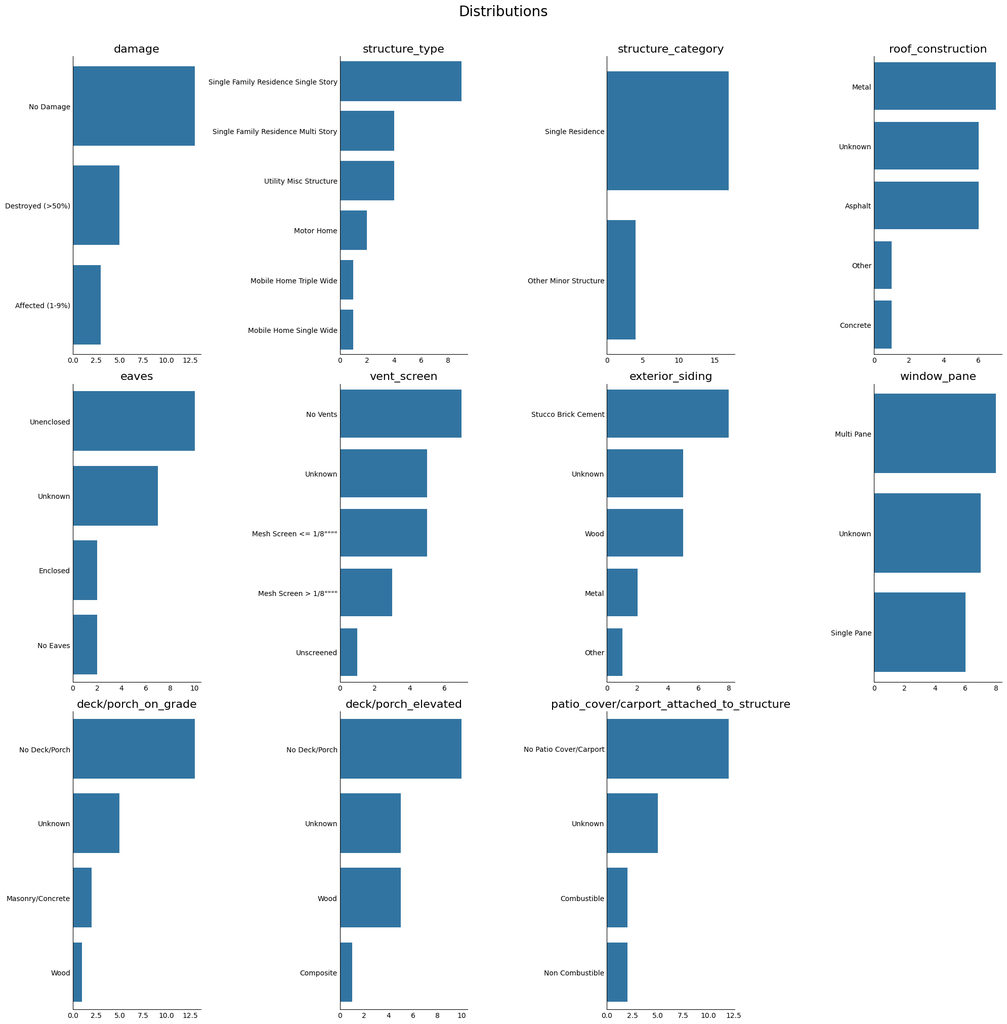

```python
fig = plt.figure(figsize=(20, 20))
plt.suptitle("Distributions", fontsize=20, y=1.01)

for i, col in enumerate(df_sample.columns):
    ax = fig.add_subplot(3, 4, i + 1)
    sns.countplot(data=df_sample, y=col, ax=ax, order=df_sample[col].value_counts().index)
    plt.xlabel('')
    plt.ylabel('')
    plt.title(col, fontsize=16)
    plt.tick_params('both', length=0)

sns.despine()
plt.tight_layout()
plt.savefig('/content/distributions.png', bbox_inches='tight')

plt.show()
```

The key takeaway is that the majority of structures were either completely `destroyed` or emerged from the fires untouched with `no damage`. This stark contrast highlights the extremes in structural outcomes, with relatively few falling into intermediate damage categories. Such findings could guide further investigation into factors contributing to these outcomes, such as location, construction materials, or fire prevention measures.

#### Scatter Plots

No numerical data would gain any advantage from being represented through a scatter plot.

# Project Milestone 3: Modeling

**CIS 4567.02**

**Project Group 4**

In this section, we will finalize our data transformations as well as perform our classification modeling utilizing Logistic Regression and Random Forest, along with results interpretation and reports.

## Correlation Analysis

```python
spark_df_cleaned.printSchema()
```

```
root
 |-- damage: string (nullable = true)
 |-- structure_type: string (nullable = true)
 |-- structure_category: string (nullable = true)
 |-- roof_construction: string (nullable = true)
 |-- eaves: string (nullable = true)
 |-- vent_screen: string (nullable = true)
 |-- exterior_siding: string (nullable = true)
 |-- window_pane: string (nullable = true)
 |-- deck/porch_on_grade: string (nullable = true)
 |-- deck/porch_elevated: string (nullable = true)
 |-- patio_cover/carport_attached_to_structure: string (nullable = true)
```

Because all features are categorical, we cannot apply Pearson's correlation directly to the raw data. While one-hot encoding technically produces numeric flags, those binary vectors measure only category co-occurrence.

## Data Preprocessing

We will utilize a Pipeline class from PySpark's ML module, as well as StringIndexer and OneHotEncoder to encode our categorical columns into an appropriate output.

We will also be utilizing n-1 columns (with dropLast parameter) to reduce redundancy and collinearity.

Since our data at this point does not contain any numeric features, our data is now appropriately transformed to be utilized in model training.

```python
spark_df.printSchema()
```

```
root
 |-- damage: string (nullable = true)
 |-- structure_type: string (nullable = true)
 |-- structure_category: string (nullable = true)
 |-- roof_construction: string (nullable = true)
 |-- eaves: string (nullable = true)
 |-- vent_screen: string (nullable = true)
 |-- exterior_siding: string (nullable = true)
 |-- window_pane: string (nullable = true)
 |-- deck/porch_on_grade: string (nullable = true)
 |-- deck/porch_elevated: string (nullable = true)
 |-- patio_cover/carport_attached_to_structure: string (nullable = true)
```

```python
from pyspark.ml.feature import StringIndexer, OneHotEncoder
from pyspark.ml import Pipeline
from pyspark.sql.functions import when, col

# Binarize `damage` into a 0/1 label
df2 = spark_df.withColumn(
    "label",
    when(col("damage") == "Destroyed (>50%)", 1).otherwise(0)
)

# Pick all other string columns
categorical_cols = [
    name
    for name, dtype in df2.dtypes
    if dtype == "string" and name != "damage"
]

indexers = [StringIndexer(inputCol=col, outputCol=f"{col}_Index", handleInvalid='skip') for col in categorical_cols]  # Index for Strings, skipping any null entries
encoders = [OneHotEncoder(inputCol=f"{col}_Index", outputCol=f"{col}_Encoded", dropLast=True) for col in categorical_cols]  # One Hot encodes the index columns, dropping the last category

# Create pipeline with indexers and encoders
pipeline = Pipeline(stages=indexers + encoders)

# Fit and transform the DataFrame
ohe_model = pipeline.fit(df2)
transformed_df = ohe_model.transform(df2)

# Identify indexer columns (those ending with "_Index")
indexer_cols = [col for col in transformed_df.columns if col.endswith("_Index")]

# Drop the original and indexer columns
cleaned_df = transformed_df.drop(*indexer_cols)

# Show the transformed DataFrame
cleaned_df.show()
```

```
+----------------+--------------------+--------------------+-----------------+----------+--------------------+-------------------+-----------+-------------------+-------------------+-----------------------------------------+-----+----------------------+--------------------------+--------------------…
|          damage|      structure_type|  structure_category|roof_construction|     eaves|         vent_screen|    exterior_siding|window_pane|deck/porch_on_grade|deck/porch_elevated|patio_cover/carport_attached_to_structure|label|structure_type_Encoded|structure_category_Encoded|roof_construction_En…
+----------------+--------------------+--------------------+-----------------+----------+--------------------+-------------------+-----------+-------------------+-------------------+-----------------------------------------+-----+----------------------+--------------------------+--------------------…
|    Inaccessible|Single Family Res...|    Single Residence|          Unknown|   Unknown|             Unknown|            Unknown|    Unknown|            Unknown|            Unknown|                                  Unknown|    0|        (18,[0],[1.0])|             (6,[0],[1.0])|           (10,[2],[…
|Destroyed (>50%)|Utility Misc Stru...|Other Minor Struc...|            Metal|  No Eaves|             Unknown|              Other|Single Pane|      No Deck/Porch|      No Deck/Porch|                     No Patio Cover/Ca...|    1|        (18,[1],[1.0])|             (6,[1],[1.0])|           (10,[1],[…
|       No Damage|          Motor Home|    Single Residence|            Metal|  No Eaves|            No Vents|              Metal|Single Pane|      No Deck/Porch|      No Deck/Porch|                     No Patio Cover/Ca...|    0|        (18,[6],[1.0])|             (6,[0],[1.0])|           (10,[1],[…
|       No Damage|Utility Misc Stru...|Other Minor Struc...|          Asphalt|Unenclosed|            No Vents|              Vinyl| Multi Pane|   Masonry/Concrete|      No Deck/Porch|                     No Patio Cover/Ca...|    0|        (18,[1],[1.0])|             (6,[1],[1.0])|           (10,[0],[…
|       No Damage|Single Family Res...|    Single Residence|          Unknown|   Unknown|             Unknown|            Unknown|    Unknown|            Unknown|            Unknown|                                  Unknown|    0|        (18,[0],[1.0])|             (6,[0],[1.0])|           (10,[2],[…
|       No Damage|Single Family Res...|    Single Residence|          Unknown|   Unknown|             Unknown|            Unknown|    Unknown|            Unknown|            Unknown|                                  Unknown|    0|        (18,[0],[1.0])|             (6,[0],[1.0])|           (10,[2],[…
|Destroyed (>50%)|Utility Misc Stru...|Other Minor Struc...|          Unknown|   Unknown|             Unknown|            Unknown|    Unknown|      No Deck/Porch|      No Deck/Porch|                     No Patio Cover/Ca...|    1|        (18,[1],[1.0])|             (6,[1],[1.0])|           (10,[2],[…
|Destroyed (>50%)|Utility Misc Stru...|Other Minor Struc...|          Unknown|   Unknown|             Unknown|            Unknown|    Unknown|      No Deck/Porch|      No Deck/Porch|                     No Patio Cover/Ca...|    1|        (18,[1],[1.0])|             (6,[1],[1.0])|           (10,[2],[…
|Destroyed (>50%)|Utility Misc Stru...|Other Minor Struc...|          Asphalt|Unenclosed|Mesh Screen > 1/8...|               Wood|Single Pane|      No Deck/Porch|      No Deck/Porch|                     No Patio Cover/Ca...|    1|        (18,[1],[1.0])|             (6,[1],[1.0])|           (10,[0],[…
|Destroyed (>50%)|          Motor Home|    Single Residence|            Other|  No Eaves|Mesh Screen > 1/8...|              Metal|Single Pane|      No Deck/Porch|      No Deck/Porch|                     No Patio Cover/Ca...|    1|        (18,[6],[1.0])|             (6,[0],[1.0])|           (10,[7],[…
|Destroyed (>50%)|Utility Misc Stru...|Other Minor Struc...|          Asphalt|   Unknown|Mesh Screen > 1/8...|               Wood| No Windows|      No Deck/Porch|      No Deck/Porch|                     No Patio Cover/Ca...|    1|        (18,[1],[1.0])|             (6,[1],[1.0])|           (10,[0],[…
| Affected (1-9%)|Commercial Buildi...|Nonresidential Co...|            Metal|Unenclosed|Mesh Screen <= 1/...|               Wood| Multi Pane|      No Deck/Porch|               Wood|                              Combustible|    0|        (18,[4],[1.0])|             (6,[2],[1.0])|           (10,[1],[…
|Destroyed (>50%)|Mobile Home Singl...|    Single Residence|            Metal|   Unknown|Mesh Screen <= 1/...|               Wood|Single Pane|               Wood|      No Deck/Porch|                     No Patio Cover/Ca...|    1|        (18,[5],[1.0])|             (6,[0],[1.0])|           (10,[1],[…
```

[output cut: 9 more lines]

Next, we'll drop the original columns that we have encoded from.

```python
cleaned_df = cleaned_df.drop("damage","structure_type","structure_category","roof_construction",
                "eaves","vent_screen","exterior_siding","window_pane","deck/porch_on_grade",
                "deck/porch_elevated","patio_cover/carport_attached_to_structure")
cleaned_df.show()
```

```
+-----+----------------------+--------------------------+-------------------------+-------------+-------------------+-----------------------+-------------------+---------------------------+---------------------------+-------------------------------------------------+
|label|structure_type_Encoded|structure_category_Encoded|roof_construction_Encoded|eaves_Encoded|vent_screen_Encoded|exterior_siding_Encoded|window_pane_Encoded|deck/porch_on_grade_Encoded|deck/porch_elevated_Encoded|patio_cover/carport_attached_to_structure_Encoded|
+-----+----------------------+--------------------------+-------------------------+-------------+-------------------+-----------------------+-------------------+---------------------------+---------------------------+-------------------------------------------------+
|    0|        (18,[0],[1.0])|             (6,[0],[1.0])|           (10,[2],[1.0])|(5,[0],[1.0])|      (9,[0],[1.0])|         (10,[2],[1.0])|      (6,[2],[1.0])|              (5,[3],[1.0])|              (5,[3],[1.0])|                                    (4,[3],[1.0])|
|    1|        (18,[1],[1.0])|             (6,[1],[1.0])|           (10,[1],[1.0])|(5,[3],[1.0])|      (9,[0],[1.0])|         (10,[8],[1.0])|      (6,[1],[1.0])|              (5,[0],[1.0])|              (5,[0],[1.0])|                                    (4,[0],[1.0])|
|    0|        (18,[6],[1.0])|             (6,[0],[1.0])|           (10,[1],[1.0])|(5,[3],[1.0])|      (9,[2],[1.0])|         (10,[6],[1.0])|      (6,[1],[1.0])|              (5,[0],[1.0])|              (5,[0],[1.0])|                                    (4,[0],[1.0])|
|    0|        (18,[1],[1.0])|             (6,[1],[1.0])|           (10,[0],[1.0])|(5,[1],[1.0])|      (9,[2],[1.0])|         (10,[9],[1.0])|      (6,[0],[1.0])|              (5,[1],[1.0])|              (5,[0],[1.0])|                                    (4,[0],[1.0])|
|    0|        (18,[0],[1.0])|             (6,[0],[1.0])|           (10,[2],[1.0])|(5,[0],[1.0])|      (9,[0],[1.0])|         (10,[2],[1.0])|      (6,[2],[1.0])|              (5,[3],[1.0])|              (5,[3],[1.0])|                                    (4,[3],[1.0])|
|    0|        (18,[0],[1.0])|             (6,[0],[1.0])|           (10,[2],[1.0])|(5,[0],[1.0])|      (9,[0],[1.0])|         (10,[2],[1.0])|      (6,[2],[1.0])|              (5,[3],[1.0])|              (5,[3],[1.0])|                                    (4,[3],[1.0])|
|    1|        (18,[1],[1.0])|             (6,[1],[1.0])|           (10,[2],[1.0])|(5,[0],[1.0])|      (9,[0],[1.0])|         (10,[2],[1.0])|      (6,[2],[1.0])|              (5,[0],[1.0])|              (5,[0],[1.0])|                                    (4,[0],[1.0])|
|    1|        (18,[1],[1.0])|             (6,[1],[1.0])|           (10,[2],[1.0])|(5,[0],[1.0])|      (9,[0],[1.0])|         (10,[2],[1.0])|      (6,[2],[1.0])|              (5,[0],[1.0])|              (5,[0],[1.0])|                                    (4,[0],[1.0])|
|    1|        (18,[1],[1.0])|             (6,[1],[1.0])|           (10,[0],[1.0])|(5,[1],[1.0])|      (9,[1],[1.0])|         (10,[0],[1.0])|      (6,[1],[1.0])|              (5,[0],[1.0])|              (5,[0],[1.0])|                                    (4,[0],[1.0])|
|    1|        (18,[6],[1.0])|             (6,[0],[1.0])|           (10,[7],[1.0])|(5,[3],[1.0])|      (9,[1],[1.0])|         (10,[6],[1.0])|      (6,[1],[1.0])|              (5,[0],[1.0])|              (5,[0],[1.0])|                                    (4,[0],[1.0])|
|    1|        (18,[1],[1.0])|             (6,[1],[1.0])|           (10,[0],[1.0])|(5,[0],[1.0])|      (9,[1],[1.0])|         (10,[0],[1.0])|      (6,[3],[1.0])|              (5,[0],[1.0])|              (5,[0],[1.0])|                                    (4,[0],[1.0])|
|    0|        (18,[4],[1.0])|             (6,[2],[1.0])|           (10,[1],[1.0])|(5,[1],[1.0])|      (9,[3],[1.0])|         (10,[0],[1.0])|      (6,[0],[1.0])|              (5,[0],[1.0])|              (5,[2],[1.0])|                                    (4,[2],[1.0])|
|    1|        (18,[5],[1.0])|             (6,[0],[1.0])|           (10,[1],[1.0])|(5,[0],[1.0])|      (9,[3],[1.0])|         (10,[0],[1.0])|      (6,[1],[1.0])|              (5,[4],[1.0])|              (5,[0],[1.0])|                                    (4,[0],[1.0])|
```

[output cut: 9 more lines]

```python
cleaned_df.printSchema()
```

```
root
 |-- label: integer (nullable = false)
 |-- structure_type_Encoded: vector (nullable = true)
 |-- structure_category_Encoded: vector (nullable = true)
 |-- roof_construction_Encoded: vector (nullable = true)
 |-- eaves_Encoded: vector (nullable = true)
 |-- vent_screen_Encoded: vector (nullable = true)
 |-- exterior_siding_Encoded: vector (nullable = true)
 |-- window_pane_Encoded: vector (nullable = true)
 |-- deck/porch_on_grade_Encoded: vector (nullable = true)
 |-- deck/porch_elevated_Encoded: vector (nullable = true)
 |-- patio_cover/carport_attached_to_structure_Encoded: vector (nullable = true)
```

## Modeling

Here we import the necessary modules to perform additional transformations and continue with training models.

```python
# Install older version of numpy for compatibility
!pip install numpy==1.24.1
```

```python
import pyspark.sql.functions as f
import pyspark.ml.classification as cl
import pyspark.ml.evaluation as ev
import pyspark.ml.feature as feat
import numpy as np
```

### Train/Test + VectorAssembler

Our final preparation before modeling will be splitting our data into training and testing splits (70/30 split) as well as storing our features as a vector.

```python
# Create train/test split
train_df, test_df = (
    cleaned_df
    .randomSplit([0.7, 0.3], seed=0)
)

# Store features into VectorAssembler
vectorAssembler = feat.VectorAssembler(
    inputCols=cleaned_df.columns[1:]
    , outputCol='features')
```

### Logistic Regression

```python
# Create Logistic Regression object
logReg_obj = cl.LogisticRegression(
    labelCol='label'
    , featuresCol='features'
    , regParam=0.01
    , elasticNetParam=1.0
    , family='multinomial'
)

# Create pipeline
pip = Pipeline(stages=[vectorAssembler, logReg_obj])

# Fit model
pModel = pip.fit(train_df)
```

```python
# Store results
results_logReg = (
    pModel
    .transform(test_df)
    .select('label', 'probability', 'prediction')
)

# Create evaluator
evaluator = ev.MulticlassClassificationEvaluator(
    predictionCol='prediction'
    , labelCol='label')

# Evaluate based on F1, weightedPrecision and accuracy
(
    evaluator.evaluate(results_logReg)
    , evaluator.evaluate(
        results_logReg
        , {evaluator.metricName: 'weightedPrecision'}
    )
    , evaluator.evaluate(
        results_logReg
        , {evaluator.metricName: 'accuracy'}
    )
)
```

```
(0.8775312181119445, 0.8816328762590717, 0.8774984755064706)
```

### Random Forest

```python
# Create Random Forest object
rf_obj = cl.RandomForestClassifier(
    labelCol='label'
    , featuresCol='features'
    , minInstancesPerNode=10
    , numTrees=10
    , seed=0
)

# Create pipeline
pipeline = Pipeline(
    stages=[vectorAssembler, rf_obj]
)

# Fit model
pModel = pipeline.fit(train_df)
```

```python
# Store results
results_rf = (
    pModel
    .transform(test_df)
    .select('label', 'probability', 'prediction')
)

# Create evalulator
evaluator = ev.MulticlassClassificationEvaluator(
    predictionCol='prediction'
    , labelCol='label')

# Evaluate based on F1, weightedPrecision and accuracy
(
    evaluator.evaluate(results_rf)
    , evaluator.evaluate(
        results_rf
        , {evaluator.metricName: 'weightedPrecision'}
    )
    , evaluator.evaluate(
        results_rf
        , {evaluator.metricName: 'accuracy'}
    )
)
```

```
(0.8559629349149424, 0.8575261677922598, 0.8563927095331662)
```

### Feature Importances

```python
from pyspark.ml.linalg import SparseVector

# 1. Get the feature importances as a NumPy array
importances = pModel.stages[-1].featureImportances
imp_arr = importances.toArray()

# 2. Recover the assembler and its input vector cols
assembler = pModel.stages[0]      # your VectorAssembler
vec_cols  = assembler.getInputCols()

# 3. For each vector cols, pull the category labels from the OneHotEncoderModel
indexer_models = ohe_model.stages[:len(categorical_cols)]
labels_per_col = [m.labels for m in indexer_models]

# 4. Build the full list of feature names
feature_names = []
for col_name, labels in zip(vec_cols, labels_per_col):
    for lbl in labels:
        safe = str(lbl).replace(" ", "_")
        feature_names.append(f"{col_name}_{safe}")

# 5. Pair, sort, and display
feat_imp = list(zip(feature_names, imp_arr))
feat_imp.sort(key=lambda x: x[1], reverse=True)

# Show top 10
for name, score in feat_imp[:10]:
    print(f"{name:40s}  {score:.4f}")
```

```
roof_construction_Encoded_Wood            0.1723
vent_screen_Encoded_Unscreened            0.1580
vent_screen_Encoded__                     0.0904
eaves_Encoded_Enclosed                    0.0886
window_pane_Encoded_No_Windows            0.0670
exterior_siding_Encoded_Vinyl             0.0383
deck/porch_on_grade_Encoded_Wood          0.0379
vent_screen_Encoded_Deck_Elevated         0.0359
deck/porch_elevated_Encoded_No_Deck/Porch  0.0344
exterior_siding_Encoded__                 0.0294
```

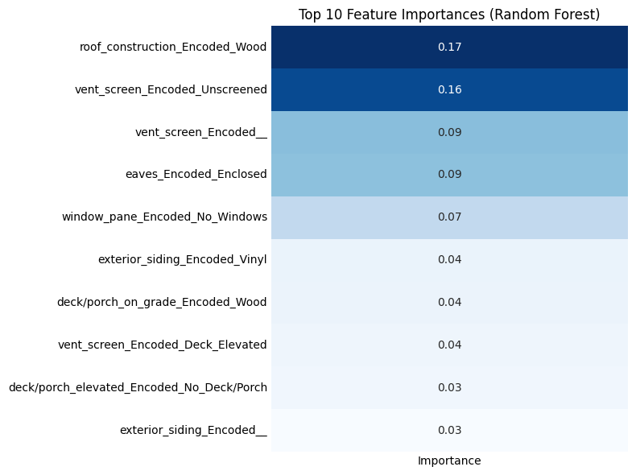

```python
# Create pandas DataFrame for visualization purposes
feat_imp_df = pd.DataFrame(feat_imp, columns=['Feature', 'Importance']).set_index('Feature')

plt.figure(figsize=(8, 6))

# Plot heatmap of feature importances
sns.heatmap(
    feat_imp_df.head(10),  # Top 10 features
    annot=True,  # Show numerical values in cells
    cmap='Blues',  # Use blue color palette
    fmt='.2f',  # Display numerical values with 3 decimal places
    cbar=False,  # Remove colorbar
)

plt.ylabel('')
plt.xlabel('')

# Customize title and remove visual ticks
plt.title('Top 10 Feature Importances (Random Forest)')
plt.tick_params('both', length=0)

plt.tight_layout()
plt.savefig('/content/feature_importances.png', bbox_inches='tight')

plt.show()
```

# Result Interpretation

**Introduction:**

**Key Findings:**

The top 3 features that damage a structure are: 1. The roof construction, 2. Vent Screens, 3. Enclosure of Eaves.

**Significance:**

Understanding and narrowing down the features that have the highest impact will allow city managers to determine what buildings need to be retrofitted to minimize/ prevent structural damage in wildfires.

**Limitations**

Due to constraints, we could not utilize the geographical information of buildings to see which areas are more prone to fire damage from the recent wildfires. Also, though we evaluated our models based on F1, weighted precision, and accuracy, the values were less than 90%. There is possible room for improvement in the models' implementation.

**Implications**

The results show that city managers should primarily focus on the type of material used in building construction. Roofs that have been constructed with wood as the construction material will result in a higher possibility of fire damage. The second most important feature is the use of vent screens. Buildings that do not have vent screens are more likely to be damaged by fires. This could be do to hot debris entering the ventilation systems and causing the fire to ignite from inside. Lastly, the third feature that should be taken notice of is the roof of constructions with enclosed eaves. We believe the type of material use to build the enclose eave would cause the strucutre to be more substance to catching on fire.

```python
!jupyter nbconvert --to html
```

[output not shown]

[output cut: 135 more lines]

[output not shown]